# Minicurso de Introdução ao R

Este material foi elaborado para o minicurso do XII Workshop de Férias em Genética e Melhoramento de Plantas pelos alunos de pós-graduação Cristiane Taniguti, Fernando Correr, Lorena Batista e Ana Letycia dos laboratórios de Genética Estatística e Laboratório de Bioinformática aplicada à Bioenergia da ESALQ-USP

Você pode encontrar os materiais de cursos de R já realizados pela mesma equipe [neste site](http://cristianetaniguti.github.io/Workshop_genetica_esalq/). O curso realizado junto com o grupo gvenck teve maior duração que os apresentados nos Workshops, por isso contém um material mais completo, caso queira maiores aprofundamentos no que será aqui tratado, recomendamos que dê uma olhada [no material](https://gvenck.github.io/cursoR/Intro.html).

Recomendamos também outros materiais disponíveis online, encontre uma lista [aqui](https://gvenck.github.io/cursoR/english_tutorials.html).

Sugerimos que, antes de iniciar a prática aqui descrita, siga [este tutorial](https://gvenck.github.io/cursoR/Tutorial_instalacao.html) para instalação do R e do RStudio.

# Familiarização com a interface do RStudio

A interface é separada em quatro janelas com principais funções:

- Edição de código
- Ambiente de trabalho e histórico
- Console
- Arquivos, gráficos, pacotes e ajuda

Explore cada uma das janelas. São inúmeras funcionalidades para cada uma delas, veremos algumas delas ao decorrer do curso.

## Um primeiro script

A janela de edição de código (provavelmente a localizada no canto superior esquerdo) você irá utilizar para escrever o seu código. Abra um novo script clicando no `+` no canto superior esquerdo e selecionando `R script`.

Vamos então iniciar os trabalhos com o tradicional `Hello World`. Digite no seu script:

```r
cat("Hello world")
```

```
## Hello world
```

Agora selecione a linha e aperte o botão `Run` ou utilize `Ctrl + enter`.

Ao fazer isso o seu código será processado na janela `Console`, onde aparecerá em azul (se você estiver com as cores padrão do R) o código escrito e logo em seguida o resultado desejado. A linha somente não será processada no console se houver o símbolo `#` na frente. Agora, experimente colocar `#` na frente do código escrito. E, novamente, selecione a linha e aperte `Run`.

```r
# cat("Hello world")
```

O símbolo `#` é muito utilizado para realizar **comentários** ao decorrer do código. Esta é uma ótima prática para deixar o código organizado e para que você possa lembrar mais tarde o que você mesmo/a estava pensando quando o escreveu ou para que outras pessoas possam entendê-lo. Como no exemplo:

```r
# Iniciando os trabalhos no R
cat("Hello world")
```

```
## Hello world
```

**Importante**: sempre que quiser realizar alguma alteração, edite o seu script e não diretamente no console, pois tudo o que neste é escrito, não terá como ser salvo!

Para salvar seu script, você pode utilizar a aba `Files` localizada (no padrão) no canto esquerdo inferior procurar uma localização de sua preferência, criar uma nova pasta com o nome `CursoR`. Depois, basta clicar no disquete localizado no cabeçalho do RStudio ou com `Ctrl + s` e selecionar o diretório `CursoR` criado. Scripts em R são salvos com a extensão `.R`.

## Estabelecendo diretório de trabalho

Outra boa prática no R é deixar o script no mesmo diretório onde estão seus dados brutos (arquivos de entrada no script) e os dados processados (gráficos, tabelas, etc). Para isso, vamos fazer com que o R identifique o mesmo diretório em que você salvou o script como **diretório de trabalho**, assim ele entenderá que é dali que precisa obter os dados e para la que também irá soltar resultados.

Você pode fazer isso utilizando as facilidades do RStudio, basta localizar o diretório `CursoR` pela aba `Files`, clique em `More` e depois “Set as Working Directory”. Repare que irá aparecer no console algo como:

```r
setwd("~/Documents/CursoR")
```

Ou seja, você pode utilizar este mesmo comando para realizar esta ação. Esta então será nossa pasta de trabalho. Quando estiver perdido/a ou se tiver certeza que o diretório de trabalho foi alterado utilize:

```r
getwd()
```

## Facilitando a vida com `Tab`

Agora, imagine que você tem um diretório como `~/Documentos/mestrado/semestre1/disciplina_tal/aula_tal/dados_28174/analise_276182/resultados_161/`. Não é fácil lembrar todo este caminho para escrever num comando `setwd()`.

Além da facilidade da janela do RStudio, você pode utilizar a tecla `Tab` para completar o caminho para você. Experimente buscando alguma pasta no seu computador. Basta começar a digitar o caminho e apertar `Tab`, ele irá completar o nome para você! Se você tiver mais do que um arquivo com aquele início de nome, aperte duas vezes o `Tab`, ele mostrará todas as opções.

O `Tab` funciona não só para indicar caminhos, mas também para comandos e nomes de objetos. É muito comum errarmos no código por erros de digitação, utilizar o `Tab` fará com que reduza significativamente esses erros.

# Operações básicas

Vamos então à linguagem!

O R pode funcionar como uma simples **calculadora**, que utiliza a mesma sintaxe que outros programas (como o excel):

```r
#########################
# Script Curso R

# Data: 24/07/2018
##########################

1+1.3                 #Decimal definido com "."
2*3
2^3
4/2

sqrt(4)              #raíz quadrada
log(100, base = 10)  #logarítmo na base 10
log(100)             #logarítmo com base neperiana
```

Agora, utilize as operações básicas para solucionar expressão abaixo. Lembre-se de utilizar parênteses `()` para estabelecer prioridades nas operações.

$(\frac{13+2+1.5}{3})+ log_{4}96$

Resultado esperado:

```
## [1] 8.792481
```

Os comandos `log` e `sqrt` são duas de muitas outras funções básicas que o R possui. Para todas elas o R possui uma descrição para auxiliar no seu uso, para acessar essa ajuda use:

```r
?log
```

E será aberta a descrição da função na janela `Help` do RStudio.

Se a descrição do próprio R não for suficiente para você entender como funciona a função, busque no google (de preferência em inglês). Existem diversos sites e fóruns com informações didáticas das funções do R.

## Operações com vetores

Os vetores são as estruturas mais simples trabalhadas no R. Construímos um vetor com uma sequencia numérica usando:

```r
c(1,3,2,5,2)
```

```
## [1] 1 3 2 5 2
```

Utilizamos o simbolo `:` para criar sequencias de números inteiros, como:

```r
1:10
```

```
##  [1]  1  2  3  4  5  6  7  8  9 10
```

Podemos utilizar outras funções para gerar sequencias, como:

```r
seq(from=0, to=100, by=5)
```

```
##  [1]   0   5  10  15  20  25  30  35  40  45  50  55  60  65  70  75  80
## [18]  85  90  95 100
```

```r
# ou
seq(0,100,5) # Se você já souber a ordem dos argumentos da função
```

```
##  [1]   0   5  10  15  20  25  30  35  40  45  50  55  60  65  70  75  80
## [18]  85  90  95 100
```

- Crie uma sequencia utilizando a função `seq` que varie de 4 a 30, com intervalos de 3 em 3.

```
## [1]  4  7 10 13 16 19 22 25 28
```

A função `rep` gera sequencias com números repetidos:

```r
rep(3:5, 2)
```

```
## [1] 3 4 5 3 4 5
```

```r
rep(3:5, each = 2)
```

```
## [1] 3 3 4 4 5 5
```

Podemos realizar operações utilizando esses vetores:

```r
c(1,4,3,2,5,8)*2
c(4,2,1,5,3,2)+c(5,2,6,1,3,5)
c(4,2,1,5,3,2)*c(5,2,6,1,3,5)
```

Repare que já esta ficando cansativo digitar os mesmos números repetidamente, vamos resolver isso criando **objetos** para armazenar nossos vetores e muito mais.

# Criando objetos

O armazenamento de informações em objetos e a possível manipulação desses faz do R uma linguagem *orientada por objetos*. Para criar um objeto basta atribuir valores para variáveis como a seguir:

```r
x = c(30.1,30.4,40,30.2,30.6,40.1)
# ou
x <- c(30.1,30.4,40,30.2,30.6,40.1)

y = c(0.26,0.3,0.36,0.24,0.27,0.35)
```

Os mais antigos costumam usar o sinal `<-`, mas tem a mesma função de `=`. Escolha usar o qual preferir.

Para acessar os valores dentro do objeto basta:

```r
x
```

```
## [1] 30.1 30.4 40.0 30.2 30.6 40.1
```

A linguagem é sensível à letras maiúsculas e minúsculas, portanto `x` é diferente de `X`:

```r
X
```

O objeto `X` não foi criado.

Podemos então realizar as operações com o objeto criado:

```r
x*2
x + y
x*y
```

E podemos armazenar a operação em outro objeto:

```r
z <- (x+y)/2
z
```

Podemos também aplicar algumas funções, como exemplo:

```r
sum(z)  # soma dos valores de z
```

```
## [1] 101.59
```

```r
mean(z) # média
```

```
## [1] 16.93167
```

```r
var(z)  # variância
```

```
## [1] 6.427507
```

Acessamos somente o 3º valor do vetor criado com `[]`:

```r
z[3]
```

Também podemos acessar o número da posição 2 a 4 com:

```r
z[2:4]
```

```
## [1] 15.35 20.18 15.22
```

Para obter informações do vetor criado utilize:

```r
str(z)
```

```
##  num [1:6] 15.2 15.3 20.2 15.2 15.4 ...
```

A função `str` nos diz sobre a estrutura do vetor, que se trata de um vetor **numérico** com 6 elementos.

Os vetores também podem receber outras categorias como **caracteres**:

```r
clone <- c("GRA02", "URO01", "URO03", "GRA02", "GRA01", "URO01")
```

Outra classe são os **fatores**, esses podem ser um pouco complexos de lidar.

De forma geral, fatores são valores categorizados por `levels`, como exemplo, se transformarmos nosso vetor de caracteres `clone` em fator, serão atribuidos níveis para cada uma das palavras:

```r
clone_fator <- as.factor(clone)
str(clone_fator)
```

```
##  Factor w/ 4 levels "GRA01","GRA02",..: 2 3 4 2 1 3
```

```r
levels(clone_fator)
```

```
## [1] "GRA01" "GRA02" "URO01" "URO03"
```

Dessa forma, teremos apenas 4 níveis para um vetor com 6 elementos, já que as palavras “GRA02” e “URO01” se repetem. Podemos obter o número de elementos do vetor ou o seu comprimento com:

```r
length(clone_fator)
```

```
## [1] 6
```

Também vetores **lógicos**, que recebem valores de verdadeiro ou falso:

```r
logico <- x > 40
logico   # Os elementos são maiores que 40?
```

```
## [1] FALSE FALSE FALSE FALSE FALSE  TRUE
```

Com ele podemos, por exemplo, identificar quais são as posições dos elementos maiores que 40:

```r
which(logico)  # Obtendo as posiçoes dos elementos TRUE
```

```
## [1] 6
```

```r
x[which(logico)] # Obtendo os números maiores que 40 do vetor x pela posição
```

```
## [1] 40.1
```

Encontre mais sobre outros operadores lógicos, como o `>` utilizado, neste [link](http://www.statmethods.net/management/operators.html).

**Warning**

Não é possível misturar diferentes classes dentro de um mesmo vetor, ao tentar fazer isso repare que o R irá tentar igualar para uma única classe:

```r
errado <- c(TRUE, "vish", 1)
errado
```

```
## [1] "TRUE" "vish" "1"
```

No caso, todos os elementos foram transformados em caracter.

## Matrizes

As matrizes são outra classe de objetos muito utilizadas no R, com elas podemos realizar operações de maior escala de forma automatizada.

Por serem usadas em operações, nelas somente armazenamos elementos numéricos. Para criar uma matriz, determinamos uma sequência de números e indicamos o número de linhas e colunas da matriz:

```r
X <- matrix(1:12, nrow = 6, ncol = 2)
X
```

```
##      [,1] [,2]
## [1,]    1    7
## [2,]    2    8
## [3,]    3    9
## [4,]    4   10
## [5,]    5   11
## [6,]    6   12
```

Podemos também utilizar sequencias já armazenadas em vetores para gerar uma matriz, desde que eles sejam numéricos:

```r
W <- matrix(c(x,y), nrow = 6, ncol =2)
W
```

```
##      [,1] [,2]
## [1,] 30.1 0.26
## [2,] 30.4 0.30
## [3,] 40.0 0.36
## [4,] 30.2 0.24
## [5,] 30.6 0.27
## [6,] 40.1 0.35
```

```r
W2 <- matrix(c(x,y), nrow = 6, ncol =2, byrow = T)
W2
```

```
##       [,1]  [,2]
## [1,] 30.10 30.40
## [2,] 40.00 30.20
## [3,] 30.60 40.10
## [4,]  0.26  0.30
## [5,]  0.36  0.24
## [6,]  0.27  0.35
```

Com elas podemos realizar operações matriciais:

```r
X*2
```

```
##      [,1] [,2]
## [1,]    2   14
## [2,]    4   16
## [3,]    6   18
## [4,]    8   20
## [5,]   10   22
## [6,]   12   24
```

```r
X*X
```

```
##      [,1] [,2]
## [1,]    1   49
## [2,]    4   64
## [3,]    9   81
## [4,]   16  100
## [5,]   25  121
## [6,]   36  144
```

```r
X%*%t(X)          # Multiplicação matricial
```

```
##      [,1] [,2] [,3] [,4] [,5] [,6]
## [1,]   50   58   66   74   82   90
## [2,]   58   68   78   88   98  108
## [3,]   66   78   90  102  114  126
## [4,]   74   88  102  116  130  144
## [5,]   82   98  114  130  146  162
## [6,]   90  108  126  144  162  180
```

Utilizar essas operações exige conhecimento de álgebra de matrizes, se quiser se aprofundar a respeito, o livro *Linear Models in Statistics, Rencher (2008)* possui um boa revisão à respeito. Você também pode explorar a sintaxe do R para essas operações neste [link](http://www.statmethods.net/advstats/matrix.html).

Acessamos os números internos à matriz dando as coordenadas [linha,coluna], como no exemplo:

```r
W[4,2] # Número posicionado na linha 4 e coluna 2
```

```
## [1] 0.24
```

As vezes pode ser informativo dar nomes às colunas e às linhas da matriz, fazemos isso com:

```r
colnames(W) <- c("altura", "diametro")
rownames(W) <- clone
W
```

```
##       altura diametro
## GRA02   30.1     0.26
## URO01   30.4     0.30
## URO03   40.0     0.36
## GRA02   30.2     0.24
## GRA01   30.6     0.27
## URO01   40.1     0.35
```

Essas funções `colnames` e `rownames` também funcionam nos data.frames.

## Data.frames

Diferente das matrizes, não realizamos operações com os data.frames, mas eles permitem a união de vetores com classes diferentes. Os data.frames são semelhantes à tabelas geradas em outros programas, como o excel.

Os data.frames são combinação de vetores de mesmo comprimento. Todos os que criamos até agora tem tamanho 6, verifique.

Podemos assim combiná-los em colunas de um único data.frame:

```r
campo1 <- data.frame("hibrido" = c("DKB390", "SHS7990", "SYN", "BM3063", "SHS7930"),     # Antes do sinal de "="
                     "AlturaPlantas" = c(1.5,2.0,1.6,1.8,1.3),        # estabelecemos os nomes
                     "AlturaEspiga" = c(0.3,0.4,0.2,0.1,0.25),      # das coluna
                     "NumeroFolhas" = c(rep(51:52, 2),53),
                     "NotaEstande"= c(1.5,2.0,1.6,1.8,1.3) > 1.5)
campo1
```

```
##   hibrido AlturaPlantas AlturaEspiga NumeroFolhas NotaEstande
## 1  DKB390           1.5         0.30           51       FALSE
## 2 SHS7990           2.0         0.40           52        TRUE
## 3     SYN           1.6         0.20           51        TRUE
## 4  BM3063           1.8         0.10           52        TRUE
## 5 SHS7930           1.3         0.25           53       FALSE
```

Podemos acessar cada uma das colunas com:

```r
campo1$NumeroFolhas
```

```
## [1] 51 52 51 52 53
```

Ou também com:

```r
campo1[,4]
```

```
## [1] 51 52 51 52 53
```

Aqui, o número dentro dos colchetes se refere à coluna, por ser o segundo elemento (separado por vírgula). O primeiro elemento se refere à linha. Como deixamos o primeiro elemento vazio, estaremos nos referindo a todas as linhas para aquela coluna.

Dessa forma, se quisermos obter um conteúdo específico podemos dar as coordenadas com [linha,coluna]:

```r
campo1[1,2]
```

```
## [1] 1.5
```

- Obtenha altura da primeira espiga do hibrido “SYN”.

```
## [1] 0.2
```

Mesmo se tratando de um data.frame, podemos realizar operações com os vetores numéricos que a compõe.

# Exportando e importando dados

Os objetos criados dentro do R podem ser exportados em arquivos de diversos formatos. Lembre-se que, se não definir todo o caminho que deseja depositar o arquivo, ele irá ser salvo no seu diretório de trabalho.

Para exportar o objeto no formato .RData:

```r
save(campo1, file = "campo1.RData")
```

Essa é uma forma de salvar o objeto trabalhado, se removermos ele com:

```r
rm(campo1)  # Certifique-se que salvou o objeto antes de removê-lo
```

Podemos facilmente obtê-lo novamente com:

```r
load("campo1.RData")
```

Para salvar todos os objetos do seu *workspace* use:

```r
save.image()
```

O R irá criar um arquivo `.Rdata` contendo todos os seus objetos.

Podemos exportar nossos objetos em outros formatos, como, por exemplo, `.txt` ou `.csv`. Para isso utilizamos:

```r
write.table(campo1, file = "campo1.txt", sep = ";", dec = ".", row.names = FALSE)
write.csv(campo1, file = "campo1.csv", row.names = TRUE)
```

Obs: Você pode adquirir pacotes para exportar e importar dados com outros fomatos, como exemplo o pacote `xlsx` exporta e importa dados com formato do excel.

Ao exportar há diversas opções para a formatação do arquivo, é importante considerá-las se o arquivo for ser trabalhado em outro sofware posteriormente.

Abra os arquivos gerados para visualizar sua formatação.

Esses arquivos podem ser lidos novamente pelo R, utilizando as funções e suas especificações:

```r
campo1_txt <- read.table(file = "campo1.txt", sep=";", dec=".", header = TRUE)
campo1_csv <- read.csv(file = "campo1.csv")
head(campo1_txt)
head(campo1_csv)
```

Agora que aprendemos a importar dados, vamos trabalhar com o conjunto gerado a partir do dados que vocês coletaram em campo.

Nos disponibilizamos neste link dados simulados para esse experimento, mas é bem mais legal se cada um digitar o seu! Use qualquer programa para digitar os dados, faça isso no formato de tabela, você pode exportar em qualquer formato que o R da um jeito, mas se nao quiser ter muito trabalho, expore em .csv.

Envie para nos seus dados no e-mail cursogmp@gmail.com

Adicione o seu arquivo ao seu diretório de trabalho ou indique o caminho da pasta ao importá-lo para dentro do R, como a seguir.

Aqui usaremos o argumento `stringAsFactors` que impede que o R transforme os vetores da tabela em fatores, os quais são mais difíceis de trabalhar. O argumento `na.strings` irá indicar como foram nomeados os dados perdidos. O argumento `header` indica que existe na planilha o nome das colunas.

```r
dados <- read.csv(file = "dados.csv", stringsAsFactors = FALSE, na.strings="-", header = T)
```

Vamos explorar a estrutura dos dados coletados:

```r
str(dados)
```

```
## 'data.frame':    200 obs. of  8 variables:
##  $ Tempo        : chr  "T1" "T1" "T1" "T1" ...
##  $ Bloco        : int  1 1 1 1 1 1 1 1 1 1 ...
##  $ Parcela      : int  1 1 1 1 1 2 2 2 2 2 ...
##  $ Hibrido      : chr  "DKB390" "DKB390" "DKB390" "DKB390" ...
##  $ AlturaPlantas: num  0.513 1.486 1.36 1.096 2.175 ...
##  $ AlturaEspiga : num  0.512 0.733 0.868 0.959 1.4 ...
##  $ NumeroFolhas : int  17 10 9 24 21 14 16 20 12 15 ...
##  $ Estande      : int  9 9 9 9 9 5 5 5 5 5 ...
```

```r
# também
dim(dados)
```

```
## [1] 200   8
```

Vamos alterar os nomes das colunas para nomes mais fáceis de trabalhar:

```r
colnames(dados) = c("Tempo","Bloco", "Parcela", "Hibrido", "AlturaPlantas",
                                       "AlturaEspiga", "NumeroFolhas", "Estande")
str(dados)
```

```
## 'data.frame':    200 obs. of  8 variables:
##  $ Tempo        : chr  "T1" "T1" "T1" "T1" ...
##  $ Bloco        : int  1 1 1 1 1 1 1 1 1 1 ...
##  $ Parcela      : int  1 1 1 1 1 2 2 2 2 2 ...
##  $ Hibrido      : chr  "DKB390" "DKB390" "DKB390" "DKB390" ...
##  $ AlturaPlantas: num  0.513 1.486 1.36 1.096 2.175 ...
##  $ AlturaEspiga : num  0.512 0.733 0.868 0.959 1.4 ...
##  $ NumeroFolhas : int  17 10 9 24 21 14 16 20 12 15 ...
##  $ Estande      : int  9 9 9 9 9 5 5 5 5 5 ...
```

# Estruturas condicionais

## if e else

Para nossa próxima atividade com os dados, vamos primeiro entender como funcionam as estruturas `if` e `else`.

Nas funções condicionais `if` e `else`, estabelecemos uma condição para if, se ela for verdade a atividade será realizada, caso contrário (else) outra tarefa será. Como no exemplo:

```r
if(2 >3){
  print("dois é maior que três")
} else {
  print("dois não é maior que três")
}
```

```
## [1] "dois não é maior que três"
```

```r
if(dados[3,4] < 1.5){
  print("Híbrido pequeno demais")
} else {
  print("Tamanho provavelmente adequado")
}
```

```
## [1] "Tamanho provavelmente adequado"
```

Podemos espeficiar mais do que uma condição repetindo a estrutura `if` `else`:

```r
if(dados[7,4] < 1.5){
  print("Híbrido pequeno demais")
} else if (dados[7,3] > 1.5 && dados[7,1] < 2.0){
  print("Tamanho OK")
} else {
    print("Cresceu demais")
  }
```

```
## [1] "Cresceu demais"
```

Mas repare que só é possível utilizar essas estruturas para um elemento individual do vetor, se quisermos percorrer o vetor inteiro precisamos recorrer a outro recurso.

# Estruturas de repetição

## For

Esse recurso pode ser a função `for`, uma função muito utilizada e poderosa. Ela constitui uma estrutura de loop, pois irá aplicar a mesma atividade repetidamente até atingir uma determinada condição. Veja exemplos:

```r
for(i in 1:10){
  print(i)
}
```

```
## [1] 1
## [1] 2
## [1] 3
## [1] 4
## [1] 5
## [1] 6
## [1] 7
## [1] 8
## [1] 9
## [1] 10
```

```r
test <- vector()
for(i in 1:10){
  test[i] <- i+4
}
test
```

```
##  [1]  5  6  7  8  9 10 11 12 13 14
```

Nos casos acima, `i` funciona como um index que irá variar de 1 até 10 a operação determinada entre chaves.

Para exemplificar melhor a estrutura de um `for`:

```r
for(aguas in c("pau", "pedra", "o fim do caminho", "não sei cantar mais")){
  cat("É", aguas, "\n")
}
```

```
## É pau
## É pedra
## É o fim do caminho
## É não sei cantar mais
```

Com essa estrutura, podemos repetir a operação realizada com as estruturas `if` e `else` para um vetor:

```r
molejo = c("amor", "cilada")

for(dilema in molejo){
  if(dilema == "amor"){
    cat("Não era", dilema)
  }else{
    cat(" era", dilema)
  }
}
```

```
## Não era amor era cilada
```

Aplicando ao nosso conjunto de dados

```r
for(i in 1:nrow(dados)){
  if(dados[i,5] < 1.5){
    print("Híbrido pequeno demais")
  } else if (dados[i,5] > 1.5 && dados[i,5] < 2.0){
    print("Tamanho OK")
  } else {
      print("Cresceu demais")
    }
}
```

```
## [1] "Híbrido pequeno demais"
## [1] "Híbrido pequeno demais"
## [1] "Híbrido pequeno demais"
## [1] "Híbrido pequeno demais"
## [1] "Cresceu demais"
## [1] "Híbrido pequeno demais"
## [1] "Híbrido pequeno demais"
## [1] "Cresceu demais"
## [1] "Cresceu demais"
## [1] "Híbrido pequeno demais"
## [1] "Híbrido pequeno demais"
## [1] "Tamanho OK"
## [1] "Híbrido pequeno demais"
## [1] "Cresceu demais"
## [1] "Híbrido pequeno demais"
```

[output cut: 185 more lines]

## While

Nesse tipo de estrutura de repetição a tarefa será realizada até que seja atingida determinada condição.

```r
x <- 1

while(x < 5){
  x <- x + 1
  print(x)
}
```

```
## [1] 2
## [1] 3
## [1] 4
## [1] 5
```

É muito importante que nessa estrutura a condição seja possível de ser atingida, caso contrário o loop irá funcionar infinitamente e você terá que interrompê-lo por meios externos, como, se este utilizando RStudio, clicar no simbolo em vermelho no canto direito superior da janela do console, ou apertar Ctrl+C no console.

Não é muito difícil disso acontecer, basta um pequeno erro como:

```r
x <- 1

while(x < 5){
  x + 1
  print(x)
}
```

Aqui podemos utilizar os comandos `break` e `next` para atender a outras condições, como:

```r
x <- 1

while(x < 5){
  x <- x + 1
  if(x==4) break
  print(x)
}
```

```
## [1] 2
## [1] 3
```

```r
x <- 1

while(x < 5){
  x <- x + 1
  if(x==4) next
  print(x)
}
```

```
## [1] 2
## [1] 3
## [1] 5
```

## Repeat

Esta estrutura também exige uma condição de parada, mas esta condição é necessariamente colocada dentro do bloco de código com o uso do `break`. Ela então repete o bloco de código até a condição o interrompa.

```r
x <- 1
repeat{
  x <- x+1
  print(x)
  if(x==4) break
}
```

```
## [1] 2
## [1] 3
## [1] 4
```

## Loops dentro de loops

É possível também utilizarmos estruturas de repetição dentro de estruturas de repetição. Por exemplo, se quisermos trabalhar tanto nas colunas como nas linhas de uma matrix.

```r
# Criando uma matrix vazia
ex_mat <- matrix(nrow=10, ncol=10)

# cada número dentro da matrix será o produto no índice da coluna pelo índice da linha
for(i in 1:dim(ex_mat)[1]) {
  for(j in 1:dim(ex_mat)[2]) {
    ex_mat[i,j] = i*j
  }
}
```

Fizemos um vídeo com mais detalhes sobre loops no R, aumentem nossa quantidade de views e likes por [la](https://www.youtube.com/watch?v=VYOo7I5htOw).

```r
# Criando uma matrix vazia
ex_mat <- matrix(nrow=10, ncol=10)

# cada número dentro da matrix será o produto no índice da coluna pelo índice da linha
for(i in 1:dim(ex_mat)[1]) {   # Primeiro nível, não tem espaço
  for(j in 1:dim(ex_mat)[2]) { # Segundo nível tem um espaço (tab)
    ex_mat[i,j] = i*j          # Terceiro nível tem dois espaços
  }                            # Fechei o segundo nível
}                              # Fechei o primeiro nível
```

# Elaboração de gráficos simples

Para outros dados coletados, vamos gerar alguns gráficos simples utilizando as funções básicas do R. Existem pacotes como o `ggplot2`, `plotly` e `shiny` que possuem ferramentas muito poderosas para construção de gráficos, mas exigem um pouco mais de tempo para aprendizagem de sua sintaxe.

Os tipos mais comuns já possuem funções próprias, mas outros gráficos podem ser customizados de acordo com a necessidade do usuário. Vamos iniciar com um simples gráfico de frequências (ou histograma) para os dados de `Altura de Plantas`.

```r
hist(dados$AlturaPlantas)
```

Vamos adicionar alguns argumentos para dar uma personalizada:

- `breaks` para definir os intervalos para cada barra;

```r
#### Histograma ####
#Utiliza um vetor de valores para obter as frequências
hist(dados$AlturaPlantas)
hist(dados$AlturaPlantas, breaks = 2)
hist(dados$AlturaPlantas, breaks = 15)
```

Agora tente fazer o histograma para o número de folhas, aproveite para tentar alterar alguns parâmetros. Em seguida, serão apresentados outros gráficos que poderão ser utilizados.

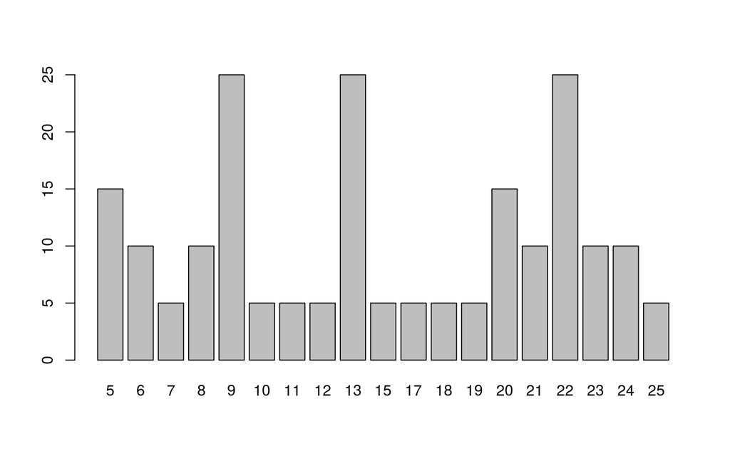

```r
#### Bar plot ####
#É um gráfico interessante quando possuímos resultados da função table
estande <- table(dados$Estande)
barplot(estande)
```

```r
#Alterando o eixo
barplot(estande, horiz = TRUE)

#Mais informações podem ser combinadas
nota_temp <- table(dados$Estande, dados$Tempo)
barplot(nota_temp)
```

```r
#Crie um objeto que corresponda ao data.frame 'dados' ordenado de acordo com a Altura (ou peso, como desejar!)
#Em seguida, tente criar o dot plot.

#### Curve ####
#Utiliza uma expressão/função
curve(x^2 + 3*x)
curve(2*x, add = TRUE, col="red")

#### Boxplot ####
#Necessita de um vetor de valores ou uma expressão
boxplot(dados$AlturaPlantas)
boxplot(dados$AlturaPlantas~dados$Tempo)

#Explore o bloxplot de outros atributos, podendo combiná-los
#Desafio: faça o boxplot da altura pela combinação de Hibridos e Blocos
boxplot(AlturaPlantas~Tempo*Hibrido, data = dados)

#### Scatter plot ####
#Utilizaremos coordenadas de pontos.
plot(x = dados$AlturaPlantas, y= dados$AlturaEspiga)
```

## Parâmetros gráficos

- `col` para adicionar cor;
- `xlab` alterar título do eixo x;
- `ylab` alterar título do eixo y;
- `main` alterar título geral;

```r
hist(dados$NumeroFolhas, breaks=6, col="blue", xlab="Número de folhas",
     ylab="Frequencia", main="Histograma do número de Folhas (Curso 2018)")
```

Se preferir, podemos usar um gráfico de densidades de Kernel como:

```r
d <- density(dados$NumeroFolhas, na.rm = TRUE)

plot(d, col="blue", xlab="Número de Folhas",
     ylab="Densidade", main="Densidade do número de Folhas (Curso 2018)")
```

Vamos explorar um pouco mais o gráfico de pontos. Vamos verificar se existe uma correlação entre o a altura de plantas e a altura da primeira espiga:

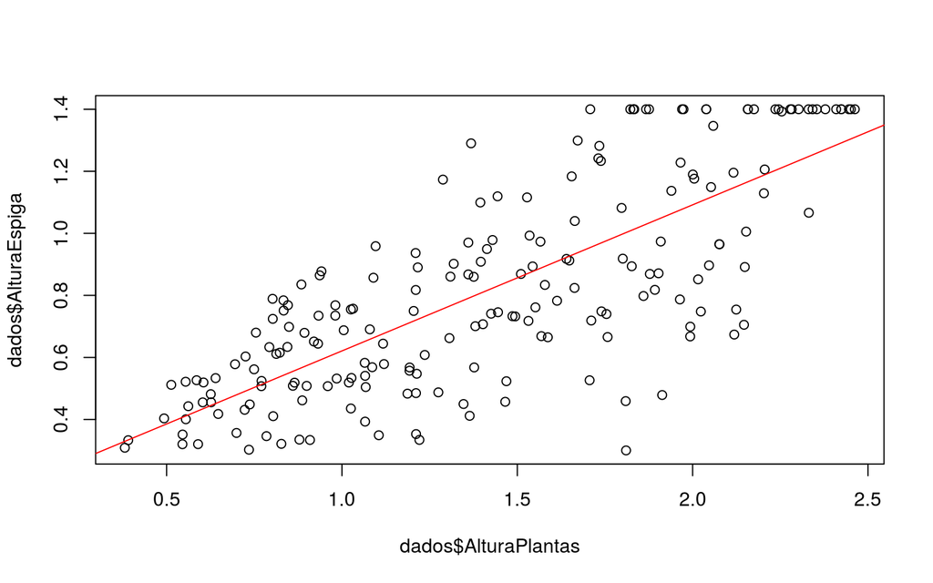

```r
#Busque explorar mais parâmetros no gráfico a seguir:
##Dica: tente alterar o nome dos eixos
plot(x = dados$AlturaPlantas, y= dados$AlturaEspiga)

#Linha de ajuste
abline(lm(AlturaEspiga ~ AlturaPlantas, data = dados), col="red")
```

```r
#Verificar a correlação:
cor(dados$AlturaPlantas, dados$AlturaEspiga)
```

```
## [1] 0.7678205
```

Alguns argumentos são específicos para cada função, busque mais informações sobre cada uma delas para entender sobre seus argumentos. Outros parâmetros gráficos mais recorrentes são os relacionados com:

- O tamanho de texto e símbolos, chamados de `cex`;
- Os símbolos de plotagem (25 ao todo), através do parâmetro `pch`;
- Há os relacionados com a fonte (`font` e `family`);
- Cores (`col`, `bg`, `fg`);

```r
#Tamanho, pontos e cores
plot(x = dados$AlturaPlantas, y= dados$AlturaEspiga,
     main = "Altura da prim. espiga  x Altura da planta", #Título principal
     xlab = "Altura de plantas", #Eixo x
     ylab = "Alturada prim. espiga", #Eixo y
     cex=2,
     cex.axis=1.5)

#Agora, busque alterar o nome dos rótulos (lab) e do título (main)
#Utilize o parâmetro 'pch=' e coloque um número de 0 a 25
#De maneira similar ao tamanho, trabalhe com as cores (utilize o color() para ver todas as cores disponíveis)

# Fontes e linhas #
plot(x = dados$AlturaPlantas, y= dados$AlturaEspiga,
     main = "Altura da prim. espiga  x Altura da planta", #Título principal
     xlab = "Altura de plantas", #Eixo x
     ylab = "Alturada prim. espiga", #Eixo y
     font=3,
     family="serif", #Fonte do seu computador (Windows: "TT Courier New")
     col="blue")
abline(lm(AlturaEspiga ~ AlturaPlantas, data = dados), col="red", lty=3)
```

# Planilha com dados reais

- Acesse aqui a planilha completa com dados reais coletados no campo dia 23/07/2018.

Leia a planilha para o seu ambiente R com:

```r
dados_compl <- read.csv("dados_completos.csv", stringsAsFactors = FALSE)

str(dados_compl) # Verifique se deu certo, são 200 obs e 8 variáveis
```

```
## 'data.frame':    200 obs. of  8 variables:
##  $ Tempo        : int  1 1 1 1 1 1 1 1 1 1 ...
##  $ Bloco        : int  1 1 1 1 1 1 1 1 1 1 ...
##  $ Parcela      : int  1 1 1 1 1 2 2 2 2 2 ...
##  $ Hibrido      : chr  "DKB390" "DKB390" "DKB390" "DKB390" ...
##  $ AlturaPlantas: num  1.67 1.65 1.8 1.9 1.77 1.9 2.15 2.05 1.95 1.95 ...
##  $ AlturaEspiga : num  1.05 1 1.15 1.05 1.05 0.93 1.13 0.95 0.8 0.96 ...
##  $ NumeroFolhas : int  11 12 12 11 12 13 14 14 13 13 ...
##  $ Estande      : int  25 25 25 25 25 24 24 24 24 24 ...
```

# Elaboração de funções

Normalmente é uma boa prática criar um bloco de código se vai realizar aquela ação poucas vezes. Se for realizar várias vezes a ação e de uma vez só, vale a pena fazer um loop. Mas, se for realizar diversas vezes e o objeto de entrada for modificado vale a pena fazer uma função. E, na hierarquia, quando tiver acumulado muitas funções para realizar uma tarefa mais complexa, vale a pena construir um pacote.

Aqui não vamos nos aprofundar muito nesse assunto, talvez ele renda um outro módulo inteiro, vamos apenas passar noções básicas.

A função também é considerada um objeto no R, portanto você a atribui à uma variável, nesse caso à `quadra`. Então estabelecemos os argumentos da função, nesse caso `x`. Entre as chaves fica todo o corpo da função. Se você quer que a função retorne algum valor, é necessário utilizar o `return`.

```r
quadra <- function(x){
  z <- x*x
  return(z)
}

quadra(3)
```

```
## [1] 9
```

```r
quadra(4)
```

```
## [1] 16
```

```r
qualquer_nome <- 4
quadra(qualquer_nome)
```

```
## [1] 16
```

Vamos complicar um pouco e também dar mais sentido para construir uma função. Vamos definir no seu corpo várias ações antes de retornar o valor, algo que não poderia ser feito usando uma única função já pronta do R. Vamos aproveitar para explorar os dados coletados.

```r
# Número total de dados coletados
tot <- dim(dados_compl)[1]

# Média do número de folhas
mfolhas <- mean(dados_compl[,7])

# Máxima altura
max.alt <- max(dados_compl[,5])

# Outras características da árvore mais alta
ca.alt.max <- dados_compl[which(dados_compl[,5] == max(dados_compl[,5])),]

# Características da árvore mais baixa
ca.alt.min <- dados_compl[which(dados_compl[,5] == min(dados_compl[,5])),]

# Gráfico com correlação entre Altura da Planta com a Altura da Espiga
png(filename = "corr.alt.png")
plot(dados_compl[,5], dados_compl[,6], xlab = "Altura da Planta", ylab = "Altura da primeira espiga")
dev.off()
```

Em forma de função:

```r
extrair_info <- function(dados_compl){
  tot <- dim(dados_compl)[1]

  # Média do número de folhas
  mfolhas <- mean(dados_compl[,7])

  # Máxima altura
  max.alt <- max(dados_compl[,5])

  # Outras características da árvore mais alta
  ca.alt.max <- dados_compl[which(dados_compl[,5] == max(dados_compl[,5])),]

  # Características da árvore mais baixa
  ca.alt.min <- dados_compl[which(dados_compl[,5] == min(dados_compl[,5])),]

  # Gráfico com correlação entre Altura da Planta com a Altura da Espiga
  png(filename = "corr.alt.png")
  plot(dados_compl[,5], dados_compl[,6], xlab = "Altura da Planta", ylab = "Altura da primeira espiga")
  dev.off()

  return(list(tot, mfolhas, max.alt, ca.alt.max, ca.alt.min))
}

lista_info <- extrair_info(dados_compl)

# Indexação de lista
lista_info[[2]]
```

```
## [1] 12.645
```

```r
# Posso fazer com outro conjunto de dados
lista_info2 <- extrair_info(dados)
```

Posso adicionar outros argumentos na função:

```r
extrair_info <- function(dados_compl, file.name){
  tot <- dim(dados_compl)[1]

  # Média do número de folhas
  mfolhas <- mean(dados_compl[,7])

  # Máxima altura
  max.alt <- max(dados_compl[,5])

  # Outras características da árvore mais alta
  ca.alt.max <- dados_compl[which(dados_compl[,5] == max(dados_compl[,5])),]

  # Características da árvore mais baixa
  ca.alt.min <- dados_compl[which(dados_compl[,5] == min(dados_compl[,5])),]

  # Gráfico com correlação entre Altura da Planta com a Altura da Espiga
  png(filename = file.name)
  plot(dados_compl[,5], dados_compl[,6], xlab = "Altura da Planta", ylab = "Altura da primeira espiga")
  dev.off()

  return(list(tot, mfolhas, max.alt, ca.alt.max, ca.alt.min))
}

lista_info <- extrair_info(dados_compl, "outronome.png")
```

# Algumas ferramentas básicas de análise de dados

Claramente a análise de dados é algo muito específico de cada conjunto de dados e interesses. Vamos aqui mostrar alguns recursos básicos como análise de variância, regressão e teste de médias.

Algumas avaliações descritivas podem ser feitas pelo uso do `tapply` e de gráficos, como já mostrado anteriormente. A função `summary` também da informações gerais do conjunto. É possível usá-la em conjunto com o `tapply`.

```r
str(dados)
```

```
## 'data.frame':    200 obs. of  8 variables:
##  $ Tempo        : chr  "T1" "T1" "T1" "T1" ...
##  $ Bloco        : int  1 1 1 1 1 1 1 1 1 1 ...
##  $ Parcela      : int  1 1 1 1 1 2 2 2 2 2 ...
##  $ Hibrido      : chr  "DKB390" "DKB390" "DKB390" "DKB390" ...
##  $ AlturaPlantas: num  0.513 1.486 1.36 1.096 2.175 ...
##  $ AlturaEspiga : num  0.512 0.733 0.868 0.959 1.4 ...
##  $ NumeroFolhas : int  17 10 9 24 21 14 16 20 12 15 ...
##  $ Estande      : int  9 9 9 9 9 5 5 5 5 5 ...
```

```r
# Certifique-se que esta lidando com variável categórica (fator)
dados$Hibrido <- as.factor(dados$Hibrido)
dados$Parcela <- as.factor(dados$Parcela)
dados$Bloco <- as.factor(dados$Bloco)

tapply(dados$AlturaPlantas, dados$Hibrido, summary)
```

```
## $BM3063
##    Min. 1st Qu.  Median    Mean 3rd Qu.    Max.
##  0.4929  0.9329  1.4040  1.3996  1.8430  2.3419
##
## $DKB390
##    Min. 1st Qu.  Median    Mean 3rd Qu.    Max.
##  0.5132  1.1119  1.5433  1.4890  1.8617  2.4237
##
## $SHS7930
##    Min. 1st Qu.  Median    Mean 3rd Qu.    Max.
##  0.3809  0.9758  1.2814  1.2729  1.5612  2.4457
##
## $SHS7990
##    Min. 1st Qu.  Median    Mean 3rd Qu.    Max.
##  0.5456  0.8821  1.6916  1.5421  2.0092  2.4624
##
## $SYN
##    Min. 1st Qu.  Median    Mean 3rd Qu.    Max.
##  0.5543  0.8783  1.3395  1.4064  1.9231  2.4238
```

```r
tapply(dados$AlturaEspiga, dados$Hibrido, summary)
```

```
## $BM3063
##    Min. 1st Qu.  Median    Mean 3rd Qu.    Max.
##  0.3215  0.6278  0.7787  0.8694  1.2127  1.4000
##
## $DKB390
##    Min. 1st Qu.  Median    Mean 3rd Qu.    Max.
##  0.3025  0.5228  0.7581  0.8311  1.0788  1.4000
##
## $SHS7930
##    Min. 1st Qu.  Median    Mean 3rd Qu.    Max.
##  0.3089  0.5024  0.6988  0.7513  0.9179  1.4000
##
## $SHS7990
##    Min. 1st Qu.  Median    Mean 3rd Qu.    Max.
##  0.3515  0.6034  0.7495  0.8787  1.1905  1.4000
##
## $SYN
##    Min. 1st Qu.  Median    Mean 3rd Qu.    Max.
##  0.3003  0.5240  0.7447  0.7685  0.9184  1.4000
```

Qual a relaçao linear entre altura de plantas e altura da primeira espiga?

```r
mod1 <- lm(AlturaPlantas ~ AlturaEspiga, data = dados)
summary(mod1)
```

```
##
## Call:
## lm(formula = AlturaPlantas ~ AlturaEspiga, data = dados)
##
## Residuals:
##      Min       1Q   Median       3Q      Max
## -0.64267 -0.29175 -0.02413  0.23616  1.03856
##
## Coefficients:
##              Estimate Std. Error t value Pr(>|t|)
## (Intercept)   0.39565    0.06585   6.009 8.83e-09 ***
## AlturaEspiga  1.25196    0.07424  16.864  < 2e-16 ***
## ---
## Signif. codes:  0 '***' 0.001 '**' 0.01 '*' 0.05 '.' 0.1 ' ' 1
##
## Residual standard error: 0.3554 on 198 degrees of freedom
## Multiple R-squared:  0.5895, Adjusted R-squared:  0.5875
## F-statistic: 284.4 on 1 and 198 DF,  p-value: < 2.2e-16
```

Podemos falar que a altura de plantas é significativamente diferente entre hibridos?

```r
mod1 <- aov(AlturaPlantas ~ Hibrido + Tempo:Bloco + Tempo:Bloco:Parcela, data = dados)
summary(mod1)
```

```
##                      Df Sum Sq Mean Sq F value Pr(>F)
## Hibrido               4   1.68  0.4190   1.414  0.232
## Tempo:Bloco           7   2.33  0.3333   1.125  0.350
## Tempo:Bloco:Parcela  28   9.52  0.3400   1.147  0.292
## Residuals           160  47.41  0.2963
```

O p-valor nos indica se podemos considerar diferenças de altura conforme o híbrido.

Podemos também fazer um teste de médias para diferenciar a altura de plantas de cada híbrido. Aqui utilizaremos o método de Tukey:

```r
modaov <- aov(AlturaPlantas ~ Hibrido + Tempo:Bloco + Tempo:Bloco:Parcela, data = dados)
tukey.test <- TukeyHSD(x=modaov, 'Hibrido', conf.level=0.95)
tukey.test
```

```
##   Tukey multiple comparisons of means
##     95% family-wise confidence level
##
## Fit: aov(formula = AlturaPlantas ~ Hibrido + Tempo:Bloco + Tempo:Bloco:Parcela, data = dados)
##
## $Hibrido
##                         diff         lwr       upr     p adj
## DKB390-BM3063    0.089393187 -0.24645617 0.4252425 0.9481522
## SHS7930-BM3063  -0.126766566 -0.46261592 0.2090828 0.8356790
## SHS7990-BM3063   0.142456832 -0.19339252 0.4783062 0.7682548
## SYN-BM3063       0.006779435 -0.32906992 0.3426288 0.9999978
## SHS7930-DKB390  -0.216159754 -0.55200911 0.1196896 0.3912733
## SHS7990-DKB390   0.053063645 -0.28278571 0.3889130 0.9924298
## SYN-DKB390      -0.082613752 -0.41846311 0.2532356 0.9607890
## SHS7990-SHS7930  0.269223398 -0.06662596 0.6050728 0.1806541
## SYN-SHS7930      0.133546002 -0.20230335 0.4693954 0.8078109
## SYN-SHS7990     -0.135677397 -0.47152675 0.2001720 0.7986372
```

# Instalação e aplicações de pacotes

O que deixa o R ainda mais poderoso é a capacidade de incorporármos à ele novas funções chamando pacotes. Existem milhares de pacotes disponíveis no CRAN (repositorio oficial), e outros repositórios. Para cada área de estudo existem diversos pacotes disponíveis. Aqui usaremos o pacote `desplot`.

Como ele esta disponível no CRAN, para instalá-lo basta:

```r
install.packages("desplot")
```

Depois disso é necessário recrutá-lo com:

```r
library(desplot) # Este comando será necessário toda vez que for utilizar o pacote
```

Este pacote é um conjunto de funções elaboradas para gerar gráficos de campo. Você pode obter mais informações sobre ele no [manual disponível no CRAN](https://cran.r-project.org/web/packages/desplot/index.html).

Com esse pacote podemos desenhar o experimento de campo (assim como esta no papel que recebeu, mas um pouco mais bonito).

Para isso vamos adicionar duas outras colunas no nossa data.frame, com informações da posição de cada indivíduo no campo.

```r
row <- rep(rep(1:10, each=5),4)
col <- c(rep(1:5,10),rep(6:10,10), rep(11:15,10), rep(16:20,10))

dados.up <- cbind(col, row, dados_compl)
```

Para usar a função do pacote, buscamos no google por tutoriais, [aqui](https://cran.r-project.org/web/packages/desplot/vignettes/desplot_examples.html) esta aquele no qual nos baseamos para elaborarmos o código abaixo.

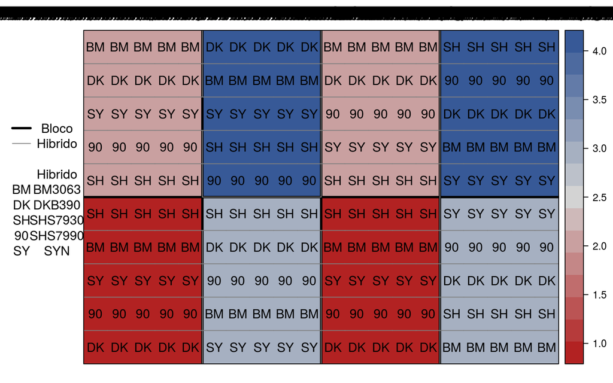

```r
desplot(Bloco ~ col+row, dados.up,
        text=Hibrido, cex=1, out1=Bloco,
        out2=Hibrido, out2.gpar=list(col = "gray50", lwd = 1, lty = 1))
```

Saindo um pouco do nosso conjunto de dados. Vamos agora utilizar um outro pacote chamado “ggmap”.

Ele esta disponível no repositório oficial do R, o CRAN, portanto para instalá-lo basta:

```r
install.packages("ggmap")
```

Depois disso é necessário recrutá-lo com:

```r
library(ggmap) # Este comando será necessário toda vez que for utilizar o pacote
```

É um pacote que utiliza recursos online para gerar mapas conforme um conjunto de dados. Você pode obter mais informações sobre ele no [manual disponível no CRAN](https://cran.r-project.org/web/packages/ggmap/ggmap.pdf).

Vamos então montar um vetor com o nome da cidade dos participantes do curso. Segue um exemplo:

```r
cidades <- c("Piracicaba - SP", "São Paulo - SP", "Pindamonhangaba - SP")
```

Vamos utilizar a função `geocode` para obter dados de longitude e latitude das cidades dos participantes do curso:

```r
part1 <- geocode(cidades[1])
```

Podemos aplicar a mesma função para todos os participantes utilizando o `for`.

```r
coord <- data.frame()
for(i in 1:length(cidades)){
  coord <- rbind(coord,geocode(cidades[i]))
}
coord
```

Pode ser que algumas coordenadas não puderam ser encontradas, é um problema de conexão com o google, mas não tem problema, vamos em frente.

Agora estabelecemos um mapa de fundo com a média das longitudes e latitudes:

```r
mapcurso <- get_map(location =
                    c(lon = mean(coord$lon, na.rm = TRUE),
                    lat = mean(coord$lat, na.rm = TRUE)),
                    zoom = 5,
                    maptype = "roadmap", scale = 2)
```

Para mais informações sobre as funções do pacote utilize `?get_map`.

Agora vamos adicionar as localizações no mapa:

[figure not shown]

```r
ggmap(mapcurso) +
  geom_point(data = coord,
             aes(x = lon, y = lat, fill = "red"),
             size = 2, shape = 21)
```

Aqui os argumentos de `aes` definem características dos pontos no mapa, `fill` indica a coloração, `size` o tamanho e `shape` o formato. Acesse outras codificações de formato [aqui](http://www.cookbook-r.com/Graphs/Shapes_and_line_types/).

# Pratique gerando relatórios no RStudio

Utilize o R no seu dia-a-dia para ir praticando a linguagem. Além das recomendações contidas na primeira apresentação, recomendamos também dar uma olhada em como gerar documentos em pdf e html usando a Markdown. Utilizamos essa metodologia para gerar este tutorial e outras apresentações do curso. Pode ser muito prático no dia-a-dia!

Para utilizar, será necessário a instalação de outros pacotes. Um deles é o próprio `rmarkdown`:

```r
install.packages("rmarkdown")
```

```r
library(rmarkdown)
```

Agora crie um arquivo .Rmd utilizando as facilidades do RStudio, clique no ícone com símbolo `+` no canto superior esquerdo. Escolha o opção `R Markdown`. Dê um título ao seu arquivo e escolha a opção `html`. Ao fazer isso, o RStudio já coloca um template inicial, ja com um cabeçalho:

```
---
title: "Teste"
author: "Eu"
date: "June 5, 2018"
output: html_document
---
```

Este é o mais simples possível, você pode otimizá-lo de diversas maneiras. Saiba mais [aqui](https://rmarkdown.rstudio.com/html_document_format.html).

O template inicial também traz alguns exemplos de sintaxe do markdown. Observe que utilizando `#` para títulos de sessões, `##` para um nível inferior (subtitulos) e assim por diante. Palavras em negrito são escritas em meia a dois `*` e existem diversas outras especificações para essa sintaxe. Veja mais sobre ela [aqui](https://www.markdownguide.org/basic-syntax).

Para compilar o código, basta clicar em `Knit`. Ele irá pedir para que o arquivo .Rmd seja salvo com algum nome em algum lugar.

O markdown também é capaz de entender diretamente a linguagem html, também a css e latex. Para essa última, o latex precisa estar instalado e todas suas dependências.

Existem alguns pacotes que fornecem templates mais robustos para produção de htmls. Para esse tutorial utilizando o pacote `rmdformats` e personalizamos suas cores. Experimente:

```r
install.packages("rmdformats")
```

Agora faça o mesmo procedimento, clique no `+`, escolha `R Markdown` e, antes de escolher um título, mude para `From Template`, escolha o `HTML readthedown template`. Copie e cole o seguinte texto e aperte `Knit`.

```
# Teste1

Isso aqui é um teste só para dar uma olhada no template

## Testinho

Subsessão

* Item

**negrito**

*itálico*

fiz um [link](https://gvenck.github.io/)!
```

Saiba mais no tutorial sobre isso no R-bloggers, que acreditamos ser um bom começo! Acesse [aqui](https://www.r-bloggers.com/how-to-create-reports-with-r-markdown-in-rstudio/).

Acesse também outros materiais em português produzidos por Cristiane Taniguti, Fernando Correr e Rodrigo Amadeu [aqui](http://cristianetaniguti.github.io/Workshop_genetica_esalq/).

Também recomendamos diversos materiais em inglês [aqui](https://gvenck.github.io/cursoR/english_tutorials.html).

Universidade de São Paulo - ESALQ

2018-07-25